# Glucose Project

Verena Steffen

Read in the data, adapt format, and explore.

```r
setwd("/home/vreni/Dropbox/Zürich/Uni Zürich Biostatistik Master/4_FS_2016/STA490_StatisticalConsulting")

glu <- read.csv("Glucose monitoring UZH/Glucose_2014.csv", sep=";", stringsAsFactors=FALSE)

# count number of rows
A <- nrow(glu)
A
```

```
## [1] 326815
```

```r
# Information about columns
colnames(glu)
```

```
## [1] "Laborbereich"        "Anforderung"         "Sex"
## [4] "Analyse.Bezeichnung" "Wert.Analyse"        "YOB"
## [7] "ANR_anon"            "PID_anon"            "Ward_anon"
```

```r
glu$Laborbereich[which(glu$Laborbereich == "Zentrum f\x9fr Labormedizin")] <- "Klinische Chemie"
glu$Laborbereich[which(glu$Laborbereich == "Point-of-Care-Diagnostik")] <- "POC"
glu$Laborbereich[which(glu$Laborbereich == "Klinische Chemie")] <- "ClinChem"
glu$Laborbereich <- as.factor(glu$Laborbereich)  # convert to factor
glu$Anforderung <- as.POSIXct(glu$Anforderung, format = "%d.%m.%Y %H:%M")  # convert to date format
glu$Sex[which(glu$Sex == "")] <- glu$Sex[which(glu$Sex == "U")] <- NA  # unknown gender to NA
glu$Sex <- as.factor(glu$Sex)  # convert to factor
glu$Analyse.Bezeichnung <- as.factor(glu$Analyse.Bezeichnung)  # convert to factor
glu$Wert.Analyse <- as.numeric(glu$Wert.Analyse)  # convert to numeric
glu$ANR_anon <- as.factor(glu$ANR_anon)  # convert to factor
glu$PID_anon <- as.factor(glu$PID_anon)  # convert to factor
glu$Ward_anon <- as.factor(glu$Ward_anon)  # convert to factor

colnames(glu) <- c("Lab", "Time", "Sex", "Analyse.Bezeichnung", "Glucose", "YOB", "ANR", "PID", "Ward")  # simplify names

glu <- glu[, -4]  # delete "Analyse.Bezeichnung" (because only one level: "Glucose")

head(glu, 1)
```

```
##   Lab              Time Sex Glucose YOB
## 1 POC 14-01-01 00:05:00   M     9.2  33
##                                                                                                                                ANR
## 1 420fc6d6b9f89c4927adb94fa02bc2e302b023a5c9fb9a4775b356a69349cf05bab5cb2e40961788767518c0399718386711c870427034a3885fff9d07c41ddd
##                                                                                                                                PID
## 1 5a4032e81f15afb231c9bb9d146b4589295143609ddae60e4d3bbae0c36cfcab5d093f9ffd4c5ea09e8d1125048f68fc5506fd181e99a03a9a908b5d0d699f03
##                                                                                                                               Ward
## 1 a522966dc76b7eef5ebdf06cef659a2640df4283ffedbd51cfff2dd5651d09f8c3d531031fa29724faffde44632dd2c84c417a6cd98602f44709212fb27b20ba
```

```r
### Exclude some patients
# 1. Lab = Morphologie  # 3
a <- which(glu$Lab == "Morphologie")
# 2. Glucose values > 70  # 3
b <- which(glu$Glucose > 70)
# 3. NA data in Sex  #796
c <- which(is.na(glu$Sex))
# exclude
glu <- glu[-c(a, b, c), ]
# Check
B <- nrow(glu)  # compare to 326815 rows before
A-B  # rows removed in total
```

```
## [1] 799
```

```r
# Remove "Morphologie" factor
glu$Lab <- factor(glu$Lab)
levels(glu$Lab)
```

```
## [1] "ClinChem" "POC"
```

```r
# Change level names for simplicity of model

# str(glu$PID)  # 50142 levels
# levels(glu$PID) <- 1:50142
#
# str(glu$Ward)  # 468 Levels
# levels(glu$Ward) <- 1:468

# # First try: Linear model
# mod1 <- lm(Glucose ~ Lab * Sex, data = glu)
# summary(mod1)
#
#
# # Some Plots
# boxplot(glu$Glucose ~ glu$Sex, main = "Glucose distribution", pch = "-", log = "y")
# boxplot(glu$Glucose ~ glu$Lab, main = "Glucose distribution", pch = "-", log = "y")

# # Variability of the two methods
# # ClinChem
# range(glu$Glucose[glu$Lab == "ClinChem"], na.rm = TRUE)
# var(glu$Glucose[glu$Lab == "ClinChem"], na.rm = TRUE)
# # POC
# range(glu$Glucose[glu$Lab == "POC"], na.rm = TRUE)
# var(glu$Glucose[glu$Lab == "POC"], na.rm = TRUE)


# Count NAs
sum(as.numeric(is.na(glu$Glucose)))
```

```
## [1] 427
```

```r
# library(lattice)
# densityplot(glu$YOB, main = "Year of birth", pch = ".")

# Look at YOB variable
# Assume all patients are below 100 years old
# Assume 0-14 --> 2000 - 2014

range(glu$YOB)
```

```
## [1]  0 99
```

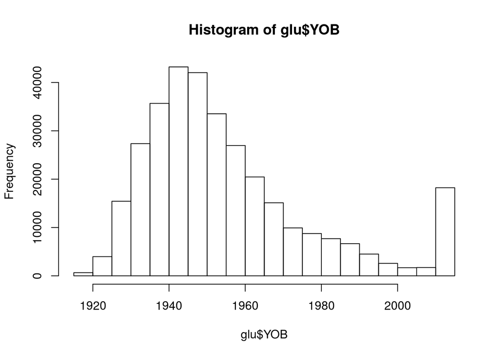

```r
# Change 15-99 to 1915 to 1999
glu$YOB[which(glu$YOB > 14)] <-
    as.numeric(paste0(19, glu$YOB[which(glu$YOB > 14)]))

# Change 0-9 to 2000-2009
glu$YOB[which(glu$YOB < 10)] <-
    as.numeric(paste0(200, glu$YOB[which(glu$YOB < 10)]))

# Change 10-14 to 2010-2014
glu$YOB[which(glu$YOB >= 10 & glu$YOB <= 14)] <-
    as.numeric(paste0(20, glu$YOB[which(glu$YOB >= 10 & glu$YOB <= 14)]))

hist(glu$YOB)
```

```r
range(glu$YOB)
```

```
## [1] 1915 2014
```

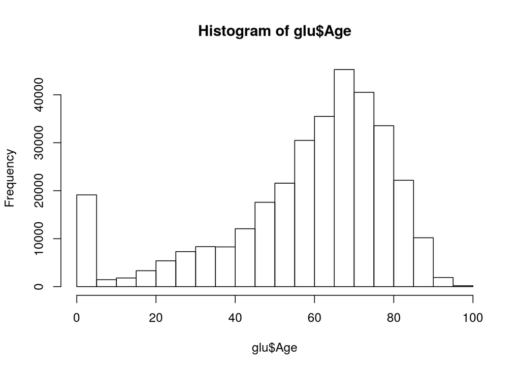

```r
# Add Age column
glu$Age <- rep(2014, nrow(glu)) - glu$YOB
hist(glu$Age)
```

```r
save(glu, file = "cleared_data_full.RData")
```

## Infos:

- Hyperglycemia in hospitalized patients has been defined as blood glucose >7.8 mmol/l
- Insulin therapy should be initiated for treatment of persistent hyperglycemia starting at a threshold ≥ 10.0 mmol/l
- Once insulin therapy is started, a target glucose range of 7.8-10.0 mmol/l is recommended for the majority of critically ill patients and noncritically ill patients
- More stringent goals, such as 6.7-7.8 mmol/l may be appropriate for selected critically ill patients, as long as this can be achieved without significant hypoglycemia
- Hypoglycemia in hospitalized patients has been defined as blood glucose≤3.9 mmol/l and severe hypoglycemia as <2.2 mmol/l

## Goals:

- An automated alerting system that warns whenever outlier values are reached and alerts the clinician to the need for monitoring individuals at risk and adequately addressing and treating hyperglycemia would be a first step to improve in-patient glucose control, thereby considerably reducing morbidity and mortality of hospitalized patients
- To retrospectively assess the in-hospital glucose control of patients at the University Hospital Bern in the year 2014

# Assessed Variables:

- Blood glucose
- Long-term glucose control: HbA1C (reflects average blood glucose over the past 2-3 months)
- Clinical Department (site of sample acquisition) (“Einsender”)
- Age
- gender
- Patient id (PID)
- Date and time of analysis
- Measurement method (“Laborbereich”): point-of-care versus core lab - “Point-of-Care-Diagnostik” - “Klinische Chemie”
- Setting: inpatient vs. outpatient Inpatient=at least two successive BG values on different days
- Comorbidity parameters (to be discussed) - Kidney function: eGFR, creatinine - liver function: ALAT, ASAT - Lipid profile: total Cholesterol, HDL, LDL, Triglycerides

## Questions:

- What does “YOB” stand for? –> Year of birth: CAUTION: ambigous
- Do we get the reason for hospitalization? It is encrypted in Ward_anon
- Should we convert YOB to age (in years) when we have more information?